# Sinking Cities Across America

# Description

New York Times article: **Across America, Big Cities Are Sinking. Here’s Why**, by Mira Rojanasakul (May 8, 2025)

https://www.nytimes.com/interactive/2025/05/08/climate/sinking-cities-us-causes-groundwater.html

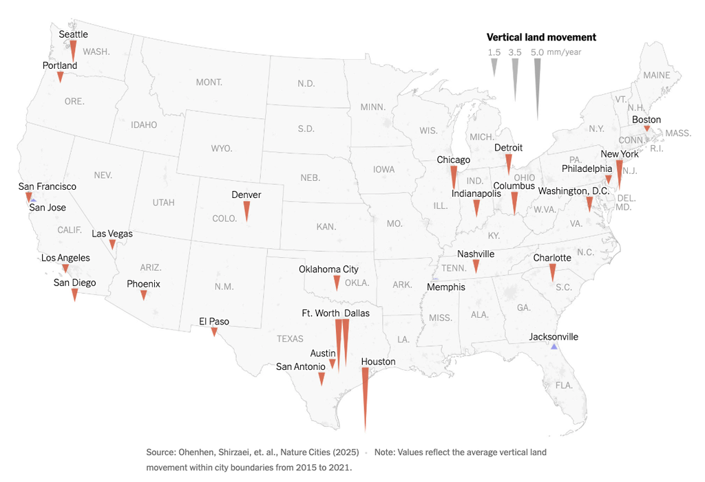

Sinking Cities US Causes Groundwater

## Details (datasheet)

Data from Nature paper: **Land subsidence risk to infrastructure in US metropolises**, by Ohenhen et al (May 8, 2025)

https://www.nature.com/articles/s44284-025-00240-y#MOESM4

Source data for figures 1-4: https://static-content.springer.com/esm/art%3A10.1038%2Fs44284-025-00240-y/MediaObjects/44284_2025_240_MOESM4_ESM.xlsx

## R packages

```r
library(tidyverse)     # ecosystem of data science packages
library(readxl)        # to import Excel files
library(sf)            # simple features (spatial vector data)
library(rnaturalearth) # database of maps
library(usmap)         # map of the U.S.
library(ggiraph)       # make ggplots interactive
```

# Data

Data Repository:

https://data.lib.vt.edu/articles/dataset/Land_Subsidence_Risk_in_US_Metropolises/27606942

Assuming that you’ve downloaded the Excel file `44284_2025_240_MOESM4_ESM.xlsx` associated to figures 1 to 4, you can use `read_excel()` to import the first spreadsheet into a tibble like so:

```r
# import data
dat = read_excel(
  path = "data/44284_2025_240_MOESM4_ESM.xlsx",
  sheet = 1,
  range = "A1:E29")
```

Because we also need the coordinates (longitude and latitude) of the cities, we used ChatGPT-4 to find such coordinates, and we curated a CSV file `land-subsidence-risk-data1.csv`. This is the data file that we’re going to use for this module.

```r
# import data
dat = read_csv(
  file = "data/land-subsidence-risk-data1.csv",
  show_col_types = FALSE) |>
  mutate(Type = case_when(
    Mean < 0 ~ "down",
    Mean >= 0 ~ "up"))

dat
```

```
# A tibble: 28 × 7
   City         State        Abbr    Mean Latitude Longitude Type
   <chr>        <chr>        <chr>  <dbl>    <dbl>     <dbl> <chr>
 1 New York     New York     NY    -2.43      40.7     -74.0 down
 2 Los Angeles  California   CA    -0.729     34.1    -118.  down
 3 Chicago      Illinois     IL    -2.32      41.9     -87.6 down
 4 Houston      Texas        TX    -5.22      29.8     -95.4 down
 5 Phoenix      Arizona      AZ    -0.846     33.4    -112.  down
 6 Philadelphia Pennsylvania PA    -0.735     40.0     -75.2 down
 7 San Antonio  Texas        TX    -1.10      29.4     -98.5 down
 8 San Diego    California   CA    -1.08      32.7    -117.  down
 9 Dallas       Texas        TX    -3.85      32.8     -96.8 down
10 San Jose     California   CA     0.219     37.3    -122.  up
# ℹ 18 more rows
```

The first four columns (`City`, `State`, `Abbr`, and `Mean`) come from the excel file. The columns `Latitude` and `Longitude` come from ChatGPT. Finally, the `Type` column indicates whether a city has been sinking (`down`) or not (`up`).

# Graphics

Let’s graph a couple of slightly different maps of the Continental U.S.

## `ne_states()` Map 1

To make the map of the continental U.S. we can use data from `ne_states()`, and then superimpose the coordinates of the cities:

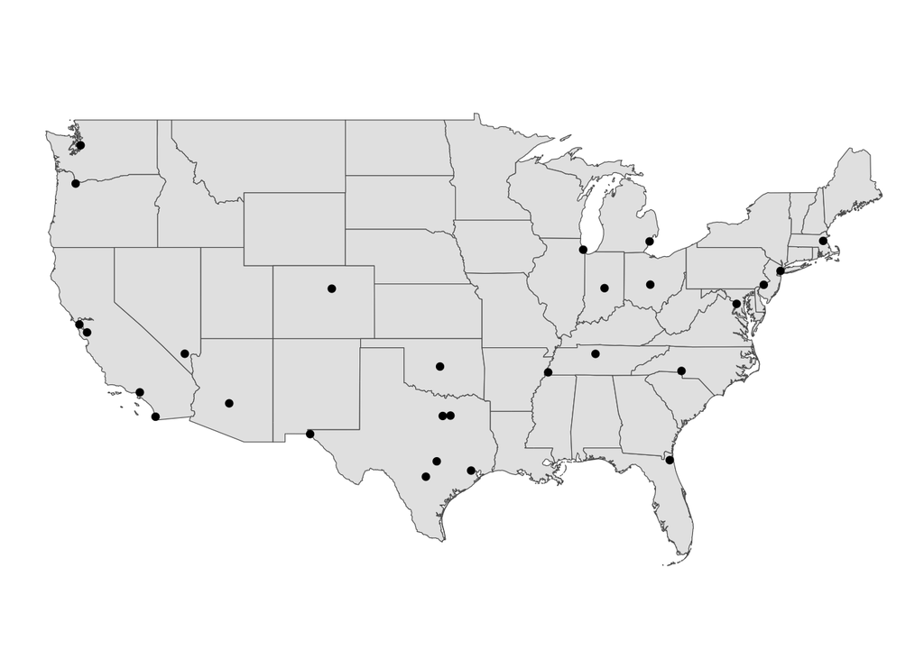

```r
# map of usa
usa_map = ne_states(country = "United States of America")

ggplot() +
  geom_sf(data = usa_map) +
  coord_sf(xlim = c(-125, -67), ylim = c(25, 50)) +
  geom_point(data = dat, aes(x = Longitude, y = Latitude)) +
  theme_void()
```

## `ne_states()` Map 2

Next, we add the names of cities via `geom_text()`, and also modify the shape of the points by mapping `shape = Type`, and color-coding `fill = Type` as well:

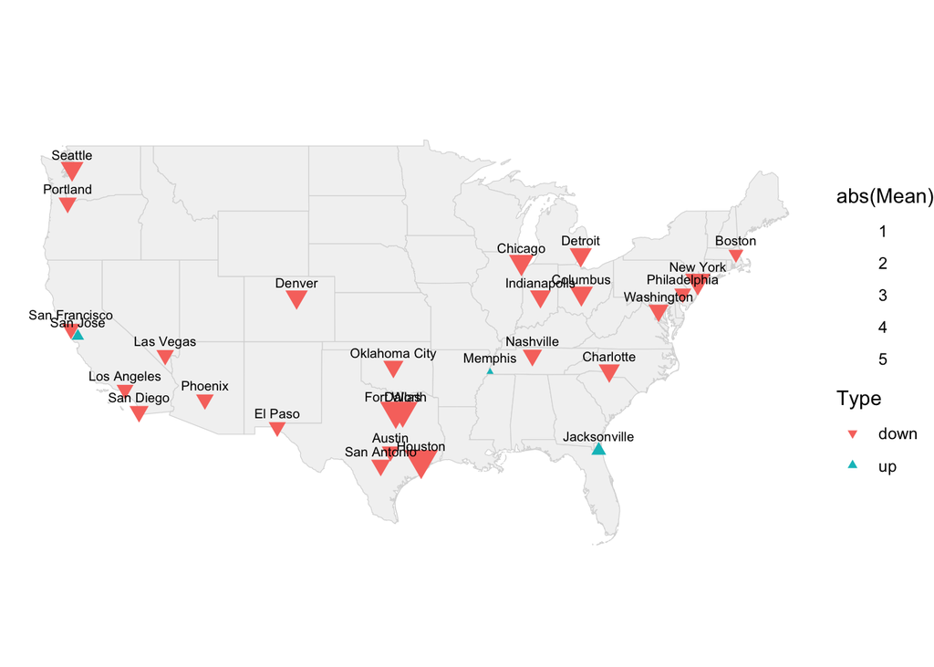

```r
ggplot() +
  geom_sf(data = usa_map, fill = "#f2f2f2" , color = "#d8d8d8") +
  coord_sf(xlim = c(-125, -67), ylim = c(25, 50)) +
  geom_point(data = dat, color = "#FFFFFF00",
             aes(x = Longitude, y = Latitude, size = abs(Mean),
                 shape = Type, fill = Type)) +
  scale_shape_manual(values = c(25, 24)) +
  geom_text(data = dat,
            vjust = -1, size = 2.5,
            aes(x = Longitude, y = Latitude, label = City)) +
  theme_void()
```

## `ne_states()` Map 3

Next, we add the names States (abbreviations). This requires to compute the centroids for each stat polygon with the function `st_centroid()`

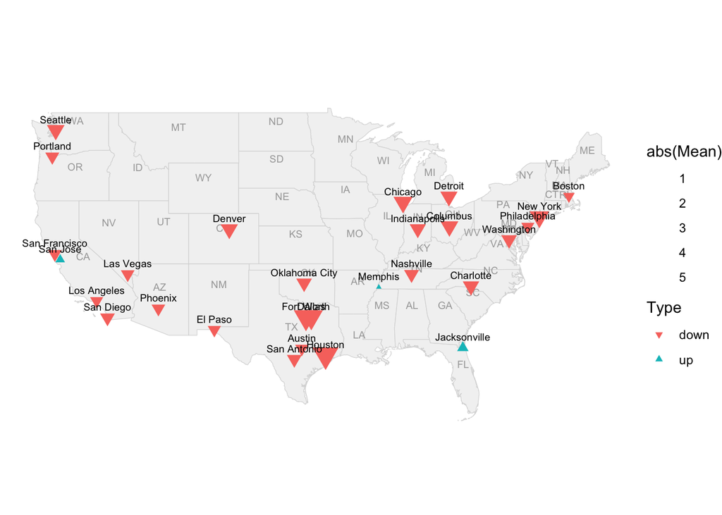

```r
state_centroids = st_centroid(usa_map)

ggplot() +
  geom_sf(data = usa_map, fill = "#f2f2f2" , color = "#d8d8d8") +
  coord_sf(xlim = c(-125, -67), ylim = c(25, 50)) +
  geom_text(data = state_centroids,
            vjust = -1, size = 2.5, color = "#a8a8a8",
            aes(x = longitude, y = latitude, label = postal)) +
  geom_point(data = dat, color = "#FFFFFF00",
             aes(x = Longitude, y = Latitude, size = abs(Mean),
                 shape = Type, fill = Type)) +
  scale_shape_manual(values = c(25, 24)) +
  geom_text(data = dat,
            vjust = -1, size = 2.5,
            aes(x = Longitude, y = Latitude, label = City)) +
  theme_void()
```

## `ne_states()` Map 4

Instead of displaying points with triangular shapes, we can substitute the type of geom to `geom_segment()`. The idea is to display vertical segments with arrowheads pointing down or up depending on whether the **Mean VLM** of a city is negative or positive.

```r
# trying to get better shapes (longer triangles or line segments?)
# fixing longitude, but stretching latitudes
dat$Latitude2 = dat$Latitude + dat$Mean
```

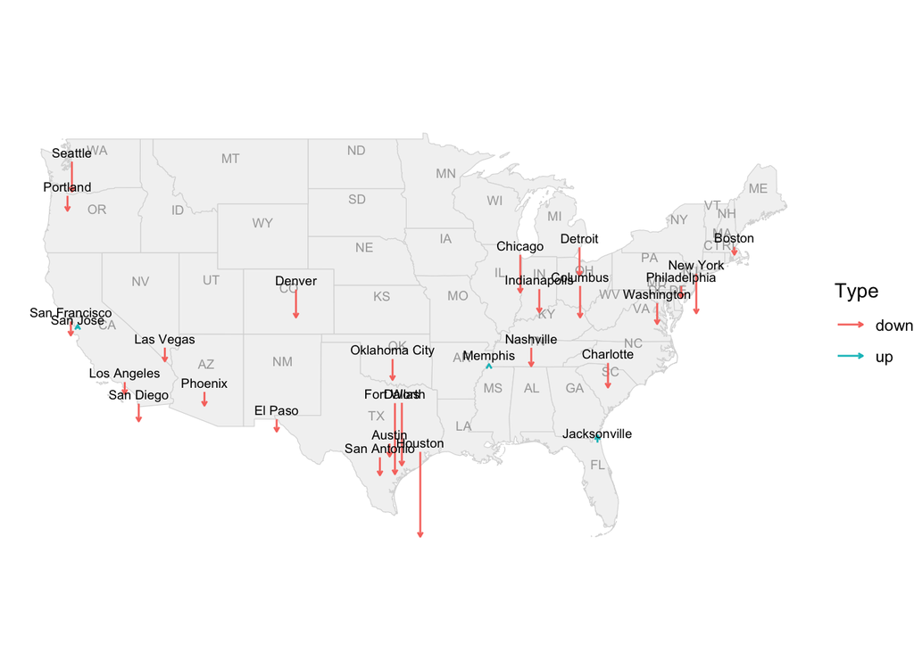

```r
ggplot() +
  geom_sf(data = usa_map, fill = "#f2f2f2" , color = "#d8d8d8") +
  coord_sf(xlim = c(-125, -67), ylim = c(25, 50)) +
  geom_text(data = state_centroids,
            vjust = -1, size = 2.5, color = "#a8a8a8",
            aes(x = longitude, y = latitude, label = postal)) +
  geom_segment(data = dat, arrow = arrow(length = unit(0.1, "cm")),
               aes(x = Longitude, y = Latitude,
                   xend = Longitude, yend = Latitude2,
                   color = Type)) +
  geom_text(data = dat,
            vjust = -0.5, size = 2.5,
            aes(x = Longitude, y = Latitude, label = City)) +
  theme_void()
```

# Maps with `usmap::us_map()`

Another option is to use map data from package `"us_map"`. This one has a closer visual appearance to the map in the NYT article that we want to replicate.

## `us_map()` Map 1

Because `us_map()` includes Alaska and Hawaii, we need to remove them from the data map. Also, we need to transform the latitude and longitude values in `dat` in order to make them compatible with the projection used by `us_map()`.

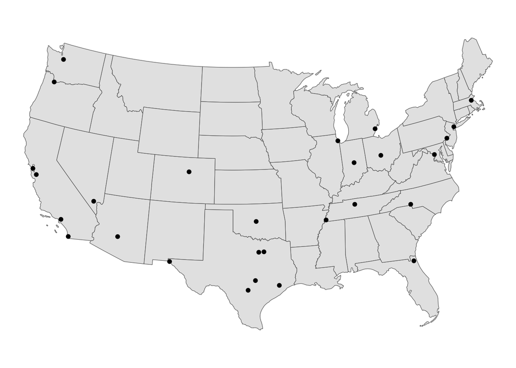

```r
# filter out Alaska and Hawaii
usa_map2 = us_map(regions = "states") |>
  filter(abbr != "AK" & abbr != "HI")

# Important: Convert spatial data (e.g. lon, lat) to "usmap" projection
dat2 = usmap_transform(
  data = dat,
  input_names = c("Longitude", "Latitude"))

# map
ggplot() +
  geom_sf(data = usa_map2) +
  geom_sf(data = dat2) +
  theme_void()
```

## `us_map()` Map 2

Adding Names of Cities and States

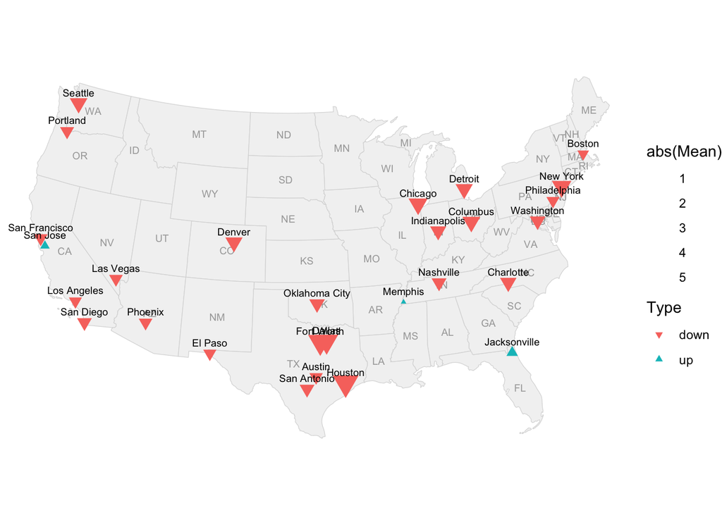

```r
ggplot() +
  geom_sf(data = usa_map2, fill = "#f2f2f2" , color = "#d8d8d8") +
  geom_sf_text(data = usa_map2, aes(label = abbr),
               color = "#a8a8a8", size = 2.5) +
  geom_sf(data = dat2, color = "#FFFFFF00",
          aes(size = abs(Mean), shape = Type, fill = Type)) +
  scale_shape_manual(values = c(25, 24)) +
  geom_sf_text(data = dat2,
            vjust = -1, size = 2.5,
            aes(label = City)) +
  theme_void()
```

## `us_map()` Map 3

Adding vertical line segments with the `geom_segment()` function, and also the `after_stat()` transformation and `stat_sf_coordinates()`.

See https://ggplot2.tidyverse.org/reference/stat_sf_coordinates.html for details about this approach.

Note: It would be nice to add an arrowhead but given the coordinate values used by `us_map()`, I’m getting some arrowheads in the wrong direction :(

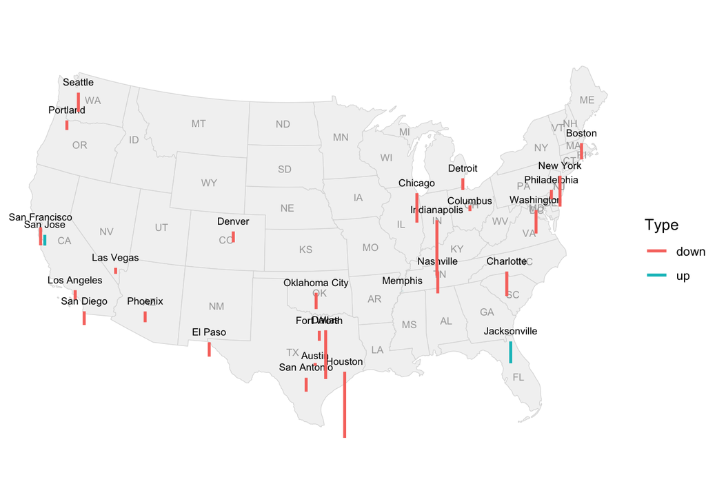

```r
ggplot() +
  geom_sf(data = usa_map2, fill = "#f2f2f2" , color = "#d8d8d8") +
  geom_sf_text(data = usa_map2, aes(label = abbr),
               color = "#a8a8a8", size = 2.5) +
  geom_sf_text(data = dat2,
            vjust = -1, size = 2.5,
            aes(label = City)) +
  geom_segment(data = dat2, linewidth = 1,
               #arrow = arrow(length = unit(0.12, "cm")),
    aes(geometry = geometry,
        x = after_stat(x),
        y = after_stat(y),
        xend = after_stat(x),
        yend = after_stat(y) + 100000 * dat2$Mean,
        color = Type),
    stat = "sf_coordinates") +
  theme_void()
```